# Part IV - Complete Problem Classification

Max Chis

11/22/2021

## Intro

This section analyzes the performance of the binary classification models for the X and V variables.

I utilized the same kind of models in Regression as in Classification, and thus I do not include “Models considered and used” sections in this part. My rationale was that their performance in both domains should be broadly similar, however I also checked this by comparing them to pairwise classification algorithms.

For whatever reason, the pairwise linear models did not converge, and hence my analysis of those models were substantially more limited.

## Comparing Linear Models

### X Variables

#### Linear additive features

```r
mod_additive_x_all_b <- readRDS(here("models","mod_x_additive_all_b.Rds"))
mod_additive_x_all_b %>% broom::glance()
```

```
## # A tibble: 1 x 8
##   null.deviance df.null logLik   AIC   BIC deviance df.residual  nobs
##           <dbl>   <int>  <dbl> <dbl> <dbl>    <dbl>       <int> <int>
## 1         2612.    1898  -368.  823. 1068.     735.        1855  1899
```

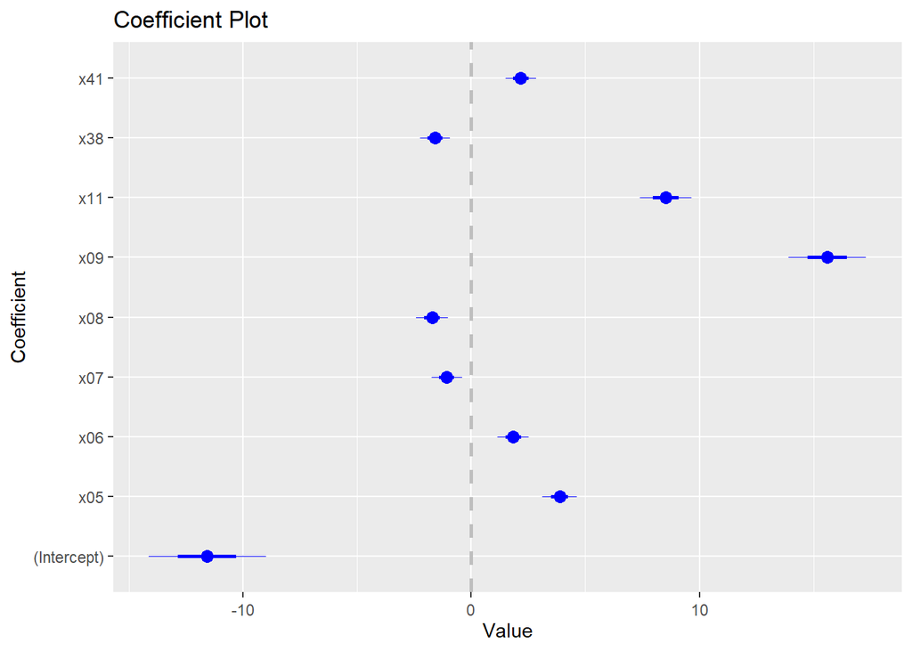

```r
#Get names of significant coefficients
sig_names <- summary(mod_additive_x_all_b)$coefficients %>% data.frame() %>% filter(Pr...z.. < 0.01) %>% rownames()
#Plot significant coefficients
mod_additive_x_all_b %>% coefplot::coefplot(coefficients=sig_names)
```

Similar to the regression scenario, x09 and x11 perform the best.

#### All pair-wise interactions between inputs

```r
mod_pairwise_x_all_b <- readRDS(here("models","mod_x_pairwise_all_b.Rds"))
mod_additive_x_all_b %>% broom::glance()
```

[output not shown]

Because this algorithm did not converge, I will not use coefplot on this.

### V Variables

#### Linear additive features

```r
mod_v_additive_all_b <- readRDS(here("models", "mod_v_additive_all_b.Rds"))
mod_v_additive_all_b %>% broom::glance()
```

```
## # A tibble: 1 x 8
##   null.deviance df.null logLik   AIC   BIC deviance df.residual  nobs
##           <dbl>   <int>  <dbl> <dbl> <dbl>    <dbl>       <int> <int>
## 1         2612.    1898  -353.  786. 1008.     706.        1859  1899
```

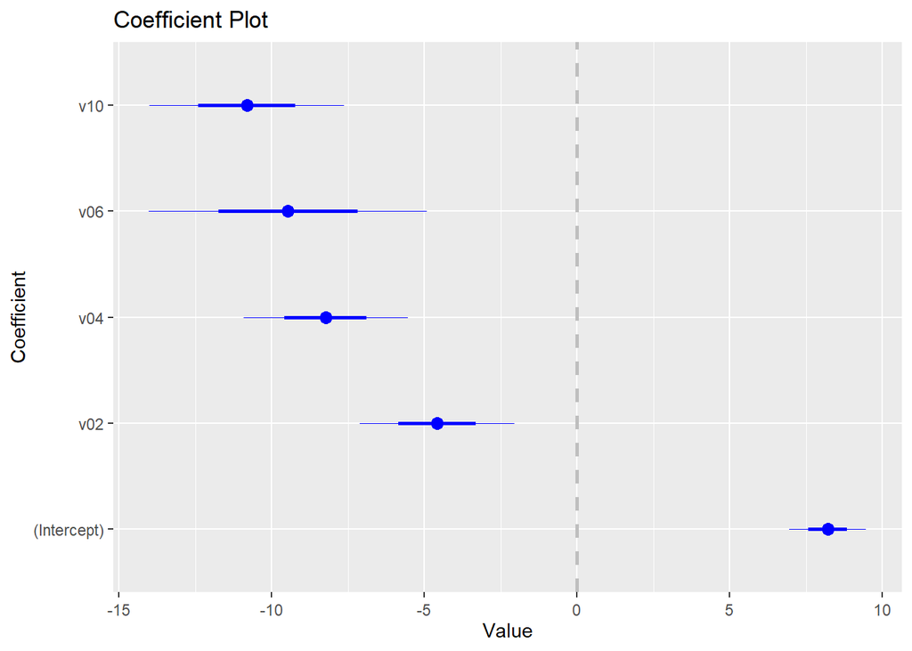

```r
#Get names of significant coefficients
sig_names <- summary(mod_v_additive_all_b)$coefficients %>% data.frame() %>% filter(Pr...z.. < 0.05) %>% rownames()
#Plot significant coefficients
mod_v_additive_all_b %>% coefplot::coefplot(coefficients=sig_names)
```

Again, as in regression, v06 and v10 performed the best. However, in contrast to the regression model, v01 is notably missing as a significant value.

#### All pair-wise interactions between inputs

```r
mod_v_pairwise_all_b <- readRDS(here("models", "mod_v_pairwise_all_b.Rds"))
mod_v_pairwise_all_b %>% broom::glance()
```

```
## # A tibble: 1 x 8
##   null.deviance df.null        logLik   AIC   BIC     deviance df.residual  nobs
##           <dbl>   <int>         <dbl> <dbl> <dbl>        <dbl>       <int> <int>
## 1         2612.    1898 -0.0000000268 1566. 5911. 0.0000000535        1116  1899
```

Because this model did not converge, I will not plot the coefficients.

## Evaluate/Compare Caret Train Models

### X Variable Models

#### Accuracy

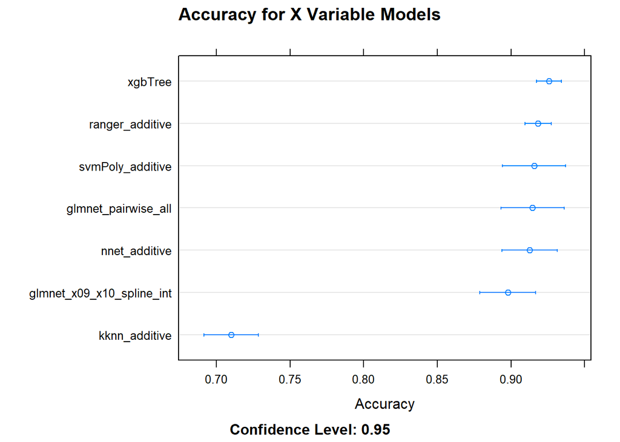

```r
xAcc <- list(
  glmnet_x09_x10_spline_int = readRDS(here("models", "mod_x_6_models_spline_x09_x11_b_Acc.Rds"))$glmnet,
  nnet_additive = readRDS(here("models", "mod_x_nnet_additive_Accuracy.Rds")),
  ranger_additive = readRDS(here("models", "mod_x_ranger_additive_Accuracy.Rds")),
  svmPoly_additive = readRDS(here("models", "mod_x_svmPoly_additive_Accuracy.Rds")),
  kknn_additive = readRDS(here("models", "mod_x_kknn_additive_Accuracy.Rds")),
  xgbTree = readRDS(here("models", "mod_x_xgbTree_additive_Accuracy.Rds")),
  glmnet_pairwise_all = readRDS(here("models", "mod_x_glmnet_pairwise_all_b_Acc.Rds"))
)
xAcc %>% resamples %>% dotplot(metric="Accuracy", main="Accuracy for X Variable Models")
```

In this case, xgbTree performed the best when evaluated in terms of accuracy. The variable importance for xgbTree is plotted below.

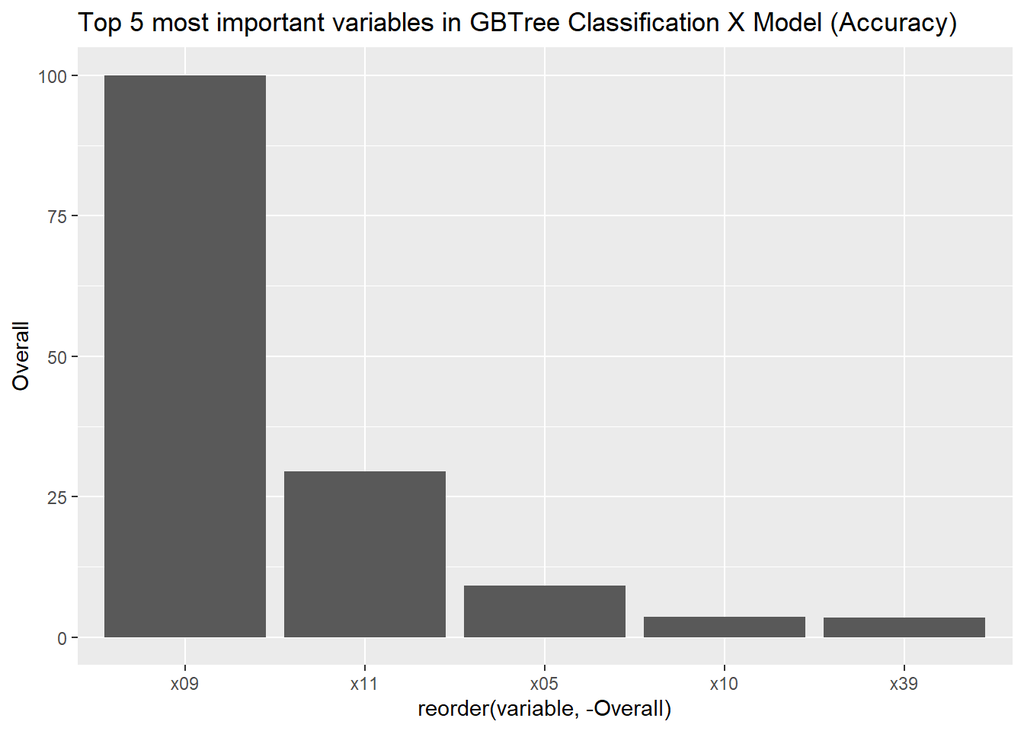

```r
(xAcc$xgbTree %>% varImp())$importance %>% tibble::rownames_to_column("variable") %>% arrange(desc(Overall)) %>% arrange(desc(Overall)) %>% top_n(5) %>%
ggplot(aes(y=Overall, x=reorder(variable, -Overall))) + geom_col() + ggtitle("Top 5 most important variables in GBTree Classification X Model (Accuracy)")
```

#### ROC

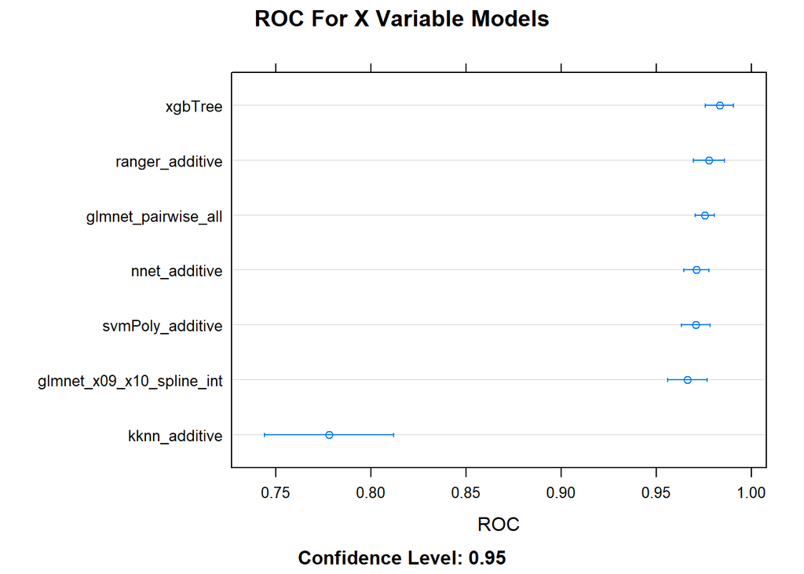

```r
xROC <- list(
  glmnet_x09_x10_spline_int = readRDS(here("models", "mod_x_6_models_spline_x09_x11_b_AUC.Rds"))$glmnet,
  nnet_additive = readRDS(here("models", "mod_x_nnet_additive_ROC.Rds")),
  ranger_additive = readRDS(here("models", "mod_x_ranger_additive_ROC.Rds")),
  svmPoly_additive = readRDS(here("models", "mod_x_svmPoly_additive_ROC.Rds")),
  kknn_additive = readRDS(here("models", "mod_x_kknn_additive_ROC.Rds")),
  xgbTree = readRDS(here("models", "mod_x_xgbTree_additive_ROC.Rds")),
  glmnet_pairwise_all = readRDS(here("models", "mod_x_glmnet_pairwise_all_b_ROC.Rds"))
)
xROC %>% resamples %>% dotplot(metric="ROC", main="ROC For X Variable Models")
```

Again, in ROC xgbTree performed best. The variable importance for xgbTree is plotted below.

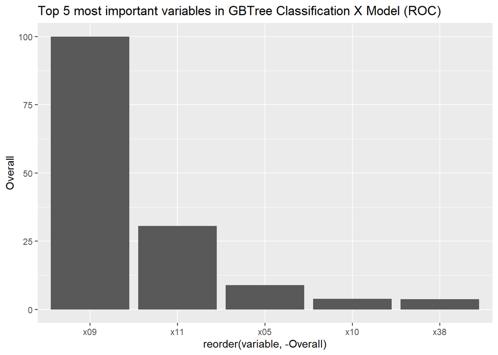

```r
(xROC$xgbTree %>% varImp())$importance %>% tibble::rownames_to_column("variable") %>% arrange(desc(Overall)) %>% arrange(desc(Overall)) %>% top_n(5) %>%
ggplot(aes(y=Overall, x=reorder(variable, -Overall))) + geom_col() + ggtitle("Top 5 most important variables in GBTree Classification X Model (ROC)")
```

### V Variable Models

#### Accuracy

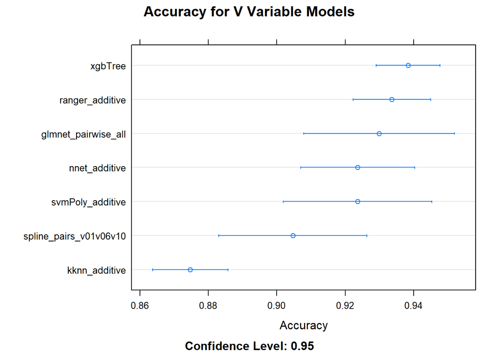

```r
vAcc <- list(
  spline_pairs_v01v06v10 = readRDS(here("models", "mod_v_6_models_spline_pairs_v01v06v10_Accuracy.Rds"))$glmnet,
  nnet_additive = readRDS(here("models", "mod_v_nnet_additive_Accuracy.Rds")),
  ranger_additive = readRDS(here("models", "mod_v_ranger_additive_Accuracy.Rds")),
  svmPoly_additive = readRDS(here("models", "mod_v_svmPoly_additive_Accuracy.Rds")),
  kknn_additive = readRDS(here("models", "mod_v_kknn_additive_Accuracy.Rds")),
  xgbTree = readRDS(here("models", "mod_v_xgbTree_additive_Accuracy.Rds")),
  glmnet_pairwise_all = readRDS(here("models", "mod_v_glmnet_pairwise_all_b_Acc.Rds"))
)
vAcc %>% resamples %>% dotplot(metric="Accuracy", main="Accuracy for V Variable Models")
```

xgbTree was found to perform the best. The variable importance is plotted below

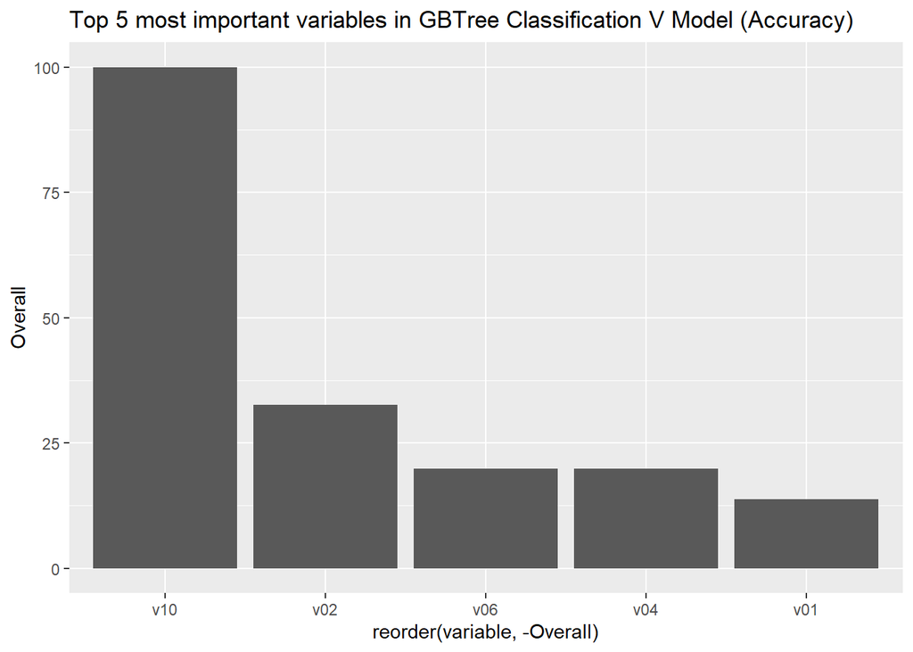

```r
(vAcc$xgbTree %>% varImp())$importance %>% tibble::rownames_to_column("variable") %>% arrange(desc(Overall)) %>% arrange(desc(Overall)) %>% top_n(5) %>%
ggplot(aes(y=Overall, x=reorder(variable, -Overall))) + geom_col() + ggtitle("Top 5 most important variables in GBTree Classification V Model (Accuracy)")
```

#### ROC

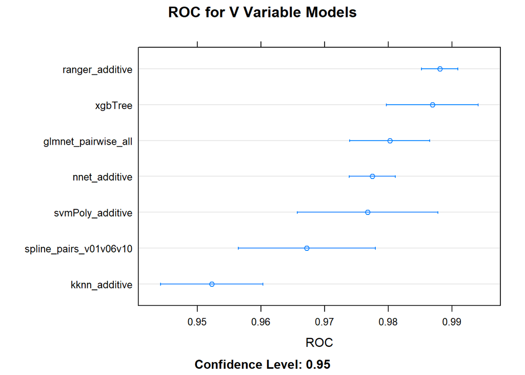

```r
vROC <- list(
  spline_pairs_v01v06v10 = readRDS(here("models", "mod_v_6_models_spline_pairs_v01v06v10_ROC.Rds"))$glmnet,
  nnet_additive = readRDS(here("models", "mod_v_nnet_additive_ROC.Rds")),
  ranger_additive = readRDS(here("models", "mod_v_ranger_additive_ROC.Rds")),
  svmPoly_additive = readRDS(here("models", "mod_v_svmPoly_additive_ROC.Rds")),
  kknn_additive = readRDS(here("models", "mod_v_kknn_additive_ROC.Rds")),
  xgbTree = readRDS(here("models", "mod_v_xgbTree_additive_ROC.Rds")),
  glmnet_pairwise_all = readRDS(here("models", "mod_v_glmnet_pairwise_all_b_ROC.Rds"))
)
vROC %>% resamples %>% dotplot(metric="ROC", main="ROC for V Variable Models")
```

Ranger was found to perform the best. The variable importance is plotted below

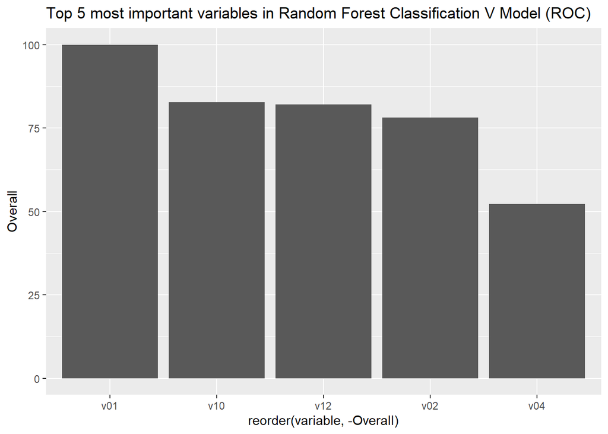

```r
(vROC$ranger_additive %>% varImp())$importance %>% tibble::rownames_to_column("variable") %>% arrange(desc(Overall)) %>% arrange(desc(Overall)) %>% top_n(5) %>%
ggplot(aes(y=Overall, x=reorder(variable, -Overall))) + geom_col() + ggtitle("Top 5 most important variables in Random Forest Classification V Model (ROC)")
```

## Best model for maximizing accuracy vs. maximizing area under ROC curve

While with x variables, the xgbBoost model proved to be the best model for maximizing accuracy and the ROC curve, with v Variables xgbTree proved best for maximizing Accuracy and ranger proved best for maximizing ROC, although the performance of both models was roughly equivalent.

## Conclusion

Overall, the random forest and Gradient boosted trees method proved best for maximizing ROC and accuracy.